# Econometrics Assignment 3

Ruoheng Du

05/15/2023

### Question 1

The data that I will use is Consumer Price Index: All Items: Total: Total for China (People’s Republic Of). This is already recorded in inflation. I will use the data from 1998 till now. During the first phase of China’s reform and opening up, from 1978 to 1997, the country suffered tremendous instability, rapid economic growth, and significant inflation. The general price-movement environment was characterized by a scarcity economy, as well as challenges connected to low degrees of international integration. Generalizations regarding this phase of development that would apply to the previous decade are not appropriate.

```r
# data starts from 1998
df <- get_fred_series("CPALTT01CNM659N", observation_start = "1998-01-01")

df <- df %>%
  rename('cpi' = 'CPALTT01CNM659N')
head(df,3)
```

|  | date | cpi |
| --- | --- | --- |
| 1 | 1998-01-01 | 0.3 |
| 2 | 1998-02-01 | -1.0 |
| 3 | 1998-03-01 | 0.7 |

```r
tail(df,3)
```

|  | date | cpi |
| --- | --- | --- |
| 300 | 2022-12-01 | 1.8 |
| 301 | 2023-01-01 | 2.1 |
| 302 | 2023-02-01 | 1.0 |

### Question 2

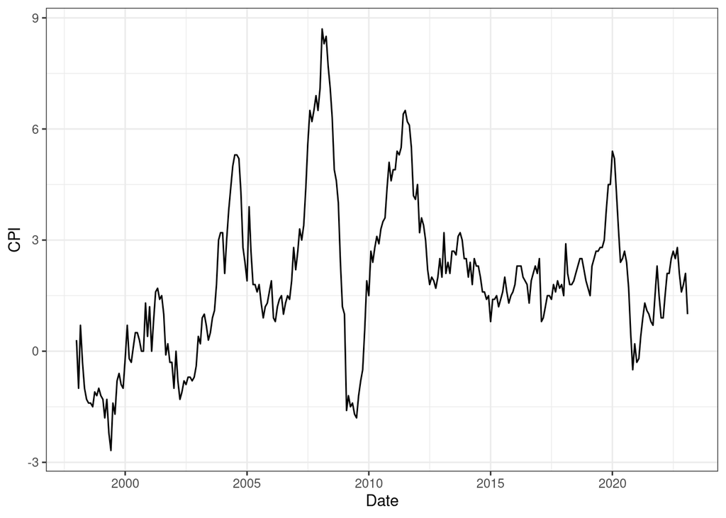

```r
# The value of CPI contains negative numbers, so it is not possible to take logarithm.
ggplot(df, aes(date, cpi))+
  geom_line() +
  theme_bw() +
  labs(x = 'Date', y = 'CPI')
```

### Question 3

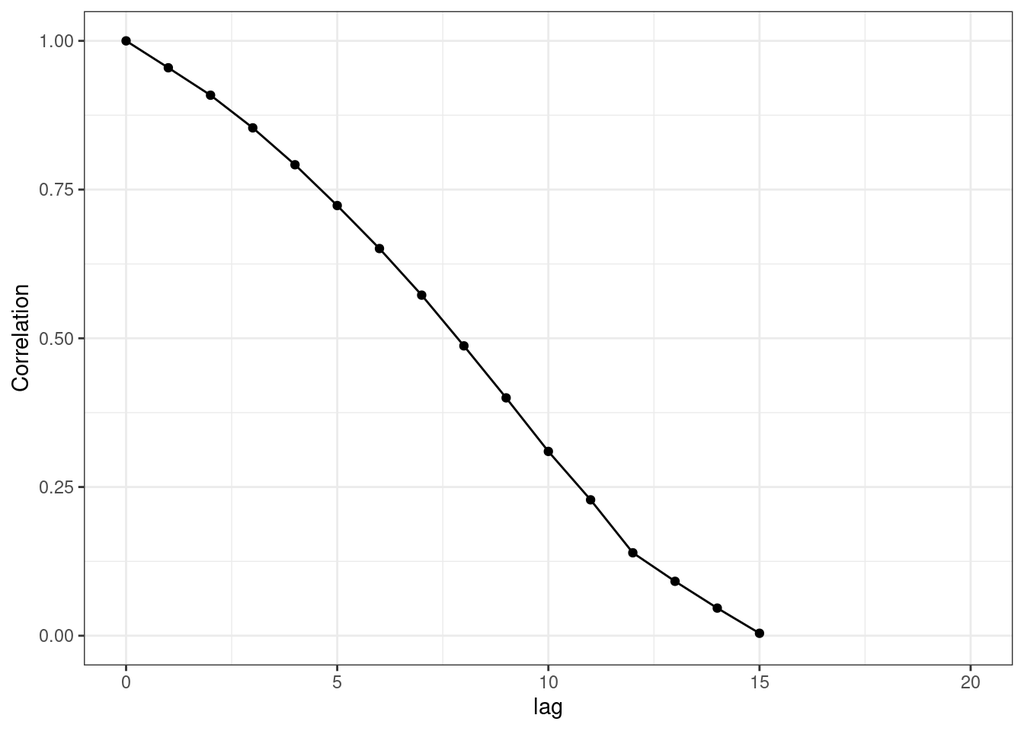

```r
# Autocorrelation including COVID-19
x <- acf(df$cpi, lag.max = 20, pl = FALSE)
acf_df <- data.frame(lag = 0:20, cpilag = x$acf)

ggplot(acf_df,aes(lag, cpilag)) +
  geom_point() +
  theme_bw() +
  ylim(0,1) +
  geom_line() +
  labs(y = 'Correlation')
```

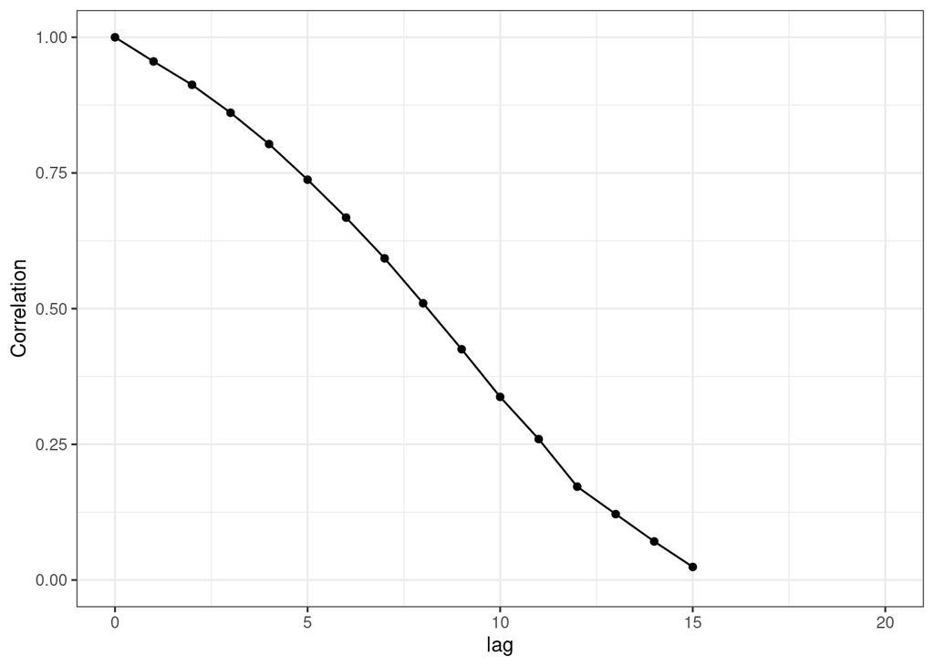

```r
# Autocorrelation excluding COVID-19
df_no_covid <- df%>%filter(date < '2019-12-31')
x_no_covid <- acf(df_no_covid$cpi, lag.max = 20, pl = FALSE)
acf_df_no_covid <- data.frame(lag = 0:20, cpilag = x_no_covid$acf)

ggplot(acf_df_no_covid,aes(lag, cpilag)) +
  geom_point() +
  theme_bw() +
  ylim(0,1) +
  geom_line() +
  labs(y = 'Correlation')
```

The plot of ACF without the pandemic is almost identical to that with the pandemic, so, I will use the full dataset. There doesn’t seem to have any seasonality and it seems that more recent time periods are better predictors because the correlation is higher. However, which AR is the most suitable is still unknown.

### Question 4

```r
#library(fUnitRoots)
#adfTest(df$cpi)
adf.test(df$cpi, nlag = 2)
```

```
## Augmented Dickey-Fuller Test
## alternative: stationary
##
## Type 1: no drift no trend
##      lag   ADF p.value
## [1,]   0 -1.88  0.0612
## [2,]   1 -1.88  0.0601
## Type 2: with drift no trend
##      lag   ADF p.value
## [1,]   0 -2.63  0.0908
## [2,]   1 -2.78  0.0667
## Type 3: with drift and trend
##      lag   ADF p.value
## [1,]   0 -2.62   0.313
## [2,]   1 -2.71   0.279
## ----
## Note: in fact, p.value = 0.01 means p.value <= 0.01
```

From the ADF test, we can reject the null hypothesis that delta is equal to 0 at 10% significance level. As a result, the data is stationary and we should model the series in level.

### Question 5

```r
# AR1
fit1 = lm(cpi ~ lag(cpi), data = df)

#BIC of AR1
BIC(fit1)
```

```
## [1] 566.1425
```

```r
# AR4
fit4 = lm(cpi ~ lag(cpi) + lag(cpi, 2) + lag(cpi, 3) + lag(cpi, 4), data = df)

# BIC of AR4
summary(fit4)
```

```
##
## Call:
## lm(formula = cpi ~ lag(cpi) + lag(cpi, 2) + lag(cpi, 3) + lag(cpi,
##     4), data = df)
##
## Residuals:
##      Min       1Q   Median       3Q      Max
## -2.32643 -0.35832  0.01434  0.33766  2.21839
##
## Coefficients:
##             Estimate Std. Error t value Pr(>|t|)
## (Intercept)  0.11190    0.04718   2.372   0.0183 *
## lag(cpi)     0.99239    0.05825  17.037   <2e-16 ***
## lag(cpi, 2)  0.09028    0.08122   1.112   0.2673
## lag(cpi, 3) -0.04474    0.07943  -0.563   0.5737
## lag(cpi, 4) -0.09471    0.05700  -1.661   0.0977 .
## ---
## Signif. codes:  0 '***' 0.001 '**' 0.01 '*' 0.05 '.' 0.1 ' ' 1
##
## Residual standard error: 0.5854 on 293 degrees of freedom
##   (4 observations deleted due to missingness)
## Multiple R-squared:   0.92,  Adjusted R-squared:  0.9189
## F-statistic: 842.2 on 4 and 293 DF,  p-value: < 2.2e-16
```

```r
BIC(fit4)
```

```
## [1] 555.7274
```

Since the BIC for the AR(4) model is smaller, we should use the AR(4) model. The goodness-of-fit for the AR(4) model is a R-squared value of 0.92, adjusted R-squared value of 0.9189 and a BIC score of 555.7274.

### Question 6

The data that I will use is Interest Rates: 3-Month or 90-Day Rates and Yields: Treasury Securities: Total for China (People’s Republic Of), and it starts from 1998 (same for my CPI dataset).

```r
dfrate <- get_fred_series("IR3TTS01CNM156N", observation_start = "1998-01-01")
dfrate <- dfrate %>%
  rename('rate' = 'IR3TTS01CNM156N')
```

```r
#library(fUnitRoots)
#adfTest(dfrate$rate)
adf.test(dfrate$rate, nlag = 2)
```

```
## Augmented Dickey-Fuller Test
## alternative: stationary
##
## Type 1: no drift no trend
##      lag   ADF p.value
## [1,]   0 -2.24  0.0248
## [2,]   1 -2.22  0.0268
## Type 2: with drift no trend
##      lag   ADF p.value
## [1,]   0 -4.63    0.01
## [2,]   1 -4.38    0.01
## Type 3: with drift and trend
##      lag   ADF p.value
## [1,]   0 -4.68    0.01
## [2,]   1 -4.46    0.01
## ----
## Note: in fact, p.value = 0.01 means p.value <= 0.01
```

From the ADF test, we can reject the null hypothesis that delta is equal to 0 at 5% significance level. As a result, the data is stationary and we should model the series in level.

```r
mdf = inner_join(df, dfrate, by = 'date')

adl1 <- lm(cpi ~ lag(cpi) + lag(cpi, 2) + lag(cpi, 3) + lag(cpi, 4) +
             lag(rate), mdf)
summary(adl1)
```

```
##
## Call:
## lm(formula = cpi ~ lag(cpi) + lag(cpi, 2) + lag(cpi, 3) + lag(cpi,
##     4) + lag(rate), data = mdf)
##
## Residuals:
##      Min       1Q   Median       3Q      Max
## -2.36133 -0.33289  0.01174  0.34293  2.18354
##
## Coefficients:
##             Estimate Std. Error t value Pr(>|t|)
## (Intercept)  0.20864    0.09833   2.122   0.0347 *
## lag(cpi)     0.99290    0.05805  17.103   <2e-16 ***
## lag(cpi, 2)  0.09475    0.08098   1.170   0.2429
## lag(cpi, 3) -0.04593    0.07910  -0.581   0.5619
## lag(cpi, 4) -0.09353    0.05679  -1.647   0.1006
## lag(rate)   -0.03025    0.02822  -1.072   0.2846
## ---
## Signif. codes:  0 '***' 0.001 '**' 0.01 '*' 0.05 '.' 0.1 ' ' 1
##
## Residual standard error: 0.5829 on 291 degrees of freedom
##   (5 observations deleted due to missingness)
## Multiple R-squared:  0.9211, Adjusted R-squared:  0.9198
## F-statistic: 679.9 on 5 and 291 DF,  p-value: < 2.2e-16
```

```r
BIC(adl1)
```

```
## [1] 556.055
```

```r
adl4 <- lm(cpi ~ lag(cpi) + lag(cpi, 2) + lag(cpi, 3) + lag(cpi, 4) +
             lag(rate) + lag(rate, 2) + lag(rate, 3) + lag(rate, 4), mdf)
BIC(adl4)
```

```
## [1] 564.5324
```

### Question 7

```r
forecast1 = as.numeric(coef(adl1)[1] + coef(adl1)[2] * tail(mdf$cpi, n = 1) + coef(adl1)[3] * mdf[nrow(mdf)-1,]$cpi + coef(adl1)[4] * mdf[nrow(mdf)-2,]$cpi + coef(adl1)[5] * mdf[nrow(mdf)-3,]$cpi + coef(adl1)[6] * tail(mdf$rate, n = 1))

forecast1
```

```
## [1] 1.079264
```

```r
forecast2 = as.numeric(coef(fit4)[1] + coef(fit4)[2] * tail(mdf$cpi, n = 1) + coef(fit4)[3] * mdf[nrow(mdf)-1,]$cpi + coef(fit4)[4] * mdf[nrow(mdf)-2,]$cpi + coef(fit4)[5] * mdf[nrow(mdf)-3,]$cpi)

forecast2
```

```
## [1] 1.061821
```

### Question 8

```r
actual_value <- tail(mdf$cpi, n = 1)

predicted_value1 <- as.numeric(coef(adl1)[1] + coef(adl1)[2] * tail(mdf$cpi, n = 1) + coef(adl1)[3] * mdf[nrow(mdf)-1,]$cpi + coef(adl1)[4] * mdf[nrow(mdf)-2,]$cpi + coef(adl1)[5] * mdf[nrow(mdf)-3,]$cpi + coef(adl1)[6] * tail(mdf$rate, n = 1))

RMSFE1 <- ((actual_value - predicted_value1)**2)**0.5

lower_range1 <- forecast1 - 1.645*RMSFE1
upper_range1 <- forecast1 + 1.645*RMSFE1

bound_90_1 <- c(lower_range1, upper_range1)
cat('The 90% forecast interval for ADL(4,1) model forecast next period is:', bound_90_1)
```

```
## The 90% forecast interval for ADL(4,1) model forecast next period is: 0.9488746 1.209654
```

```r
predicted_value2 <- as.numeric(coef(fit4)[1] + coef(fit4)[2] * tail(mdf$cpi, n = 1) + coef(fit4)[3] * mdf[nrow(mdf)-1,]$cpi + coef(fit4)[4] * mdf[nrow(mdf)-2,]$cpi + coef(fit4)[5] * mdf[nrow(mdf)-3,]$cpi)

RMSFE2 <- ((actual_value - predicted_value2)**2)**0.5

lower_range2 <- forecast2 - 1.645 * RMSFE2
upper_range2 <- forecast2 + 1.645 * RMSFE2

bound_90_2 <- c(lower_range2 ,upper_range2)

cat('The 90% forecast interval for AR(4) model forecast next period is:', bound_90_2)
```

```
## The 90% forecast interval for AR(4) model forecast next period is: 0.9601252 1.163518
```